# Incarceration rates in the US

Anchal Kohli

3/2/2022

# Introduction and Summary Information

The data sets that we are examining in this report show the incarceration rate for males, females, and individuals of different races. Through examining this data, we gather a lot of information regarding the unfair amounts of policing in certain neighborhoods which are filled with a certain demographic. We see the over policing in Black and Latin X populated neighborhoods. Additionally, we see the trends over the years during different times in history, and the events that occurred; along with how that corresponds with the increase or decrease in the jailing of certain races.I’ve decided to analyze variables through the incarceration trends database. Through this data my focus was on Black individuals who were incarcerated between years 1990-2000; how many females were incarcerated; how many LatinX individuals were incarcerated; Native American incarceration rates; and the state which had the most male jail population in 2003.

#1) How many Black individuals are incarcerated in between 1990-2000?

```
## [1] 7891239
```

```
## [1] 2601488
```

#3) Which year had the highest Male incarceration rate? The year with the highest male incarceration rate was 2008.

```
## [1] 2008
```

```
## [1] 3220014
```

[figure not shown]

#Variable comparison chart The two variables I decided to compare and analyze were the population of LatinX individuals who were jailed in comparison to the population of White individuals who were jailed. I noticed that there was a significant difference between the amount of LatinX individuals who were jailed and White individuals who were jailed. The maximum number of White individuals who were jailed was just under 7,500 while the max for LatinX individuals was way above 15,000. Both maximums took place at around 1993.

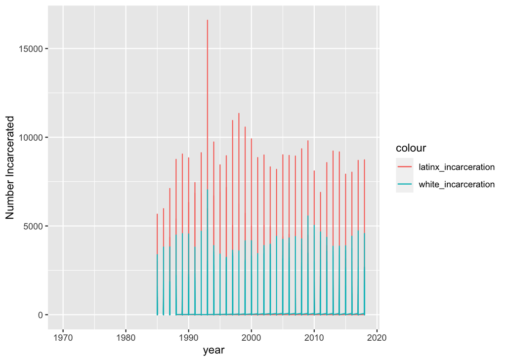